# Pesticide & neonic summaries

Olivia Burge

26 March 2015

```r
# for Tyson
fortune(298)
```

```
##
## Don't do as I say, do as Hadley does.
##    -- Barry Rowlingson (in a discussion about the workflow for writing R
##       packages, see also fortune(128))
##       R-devel (September 2011)
```

## Summary of pesticides by county over time.

```r
#setwd("/Users/Liv/Documents/NCEAS_GIT/NCEAS-RENCI_2014/PaperDrafts/")
pesticides <- read.csv("../Pesticides/allpesticidesOH.csv")
head(pesticides, 2)
```

```
##   X GEOID YEAR STATE_FIPS_CODE COUNTY_FIPS_CODE     COMPOUND State
## 1 1 39001 1992              39                1        2,4-D    OH
## 2 2 39001 1992              39                1 STREPTOMYCIN    OH
##    County.Name ANSI.class KG_EPhigh KG_EPlow USPS ANSICODE         NAME
## 1 Adams County         H1    1102.6    626.2   OH  1074014 Adams County
## 2 Adams County         H1       3.4       NA   OH  1074014 Adams County
##   POP10  HU10      ALAND  AWATER ALAND_SQMI AWATER_SQMI INTPTLAT INTPTLONG
## 1 28550 12978 1512208946 6165954      583.9       2.381    38.84    -83.47
## 2 28550 12978 1512208946 6165954      583.9       2.381    38.84    -83.47
##   PredPix reclass kg_km2agri_high kg_km2agri_low
## 1  500737       6       0.2446616          0.139
## 2  500737       6       0.0007544             NA
```

```r
range(pesticides$YEAR)
```

```
## [1] 1992 2011
```

## Question for everyone:

Have a look below - we’re missing *a lot* of data for the low estimates from what I can tell. I’ve dealt with this by excluding any row for which we don’t have both low and high estimates. For reference, I include the ‘high’ estimates when we don’t exclude the rows for which there *is* high estimates but not low. Surprising point: it’s lower!

```r
# Average application rate by year, all counties
names(pesticides)
```

```
##  [1] "X"                "GEOID"            "YEAR"
##  [4] "STATE_FIPS_CODE"  "COUNTY_FIPS_CODE" "COMPOUND"
##  [7] "State"            "County.Name"      "ANSI.class"
## [10] "KG_EPhigh"        "KG_EPlow"         "USPS"
## [13] "ANSICODE"         "NAME"             "POP10"
## [16] "HU10"             "ALAND"            "AWATER"
## [19] "ALAND_SQMI"       "AWATER_SQMI"      "INTPTLAT"
## [22] "INTPTLONG"        "PredPix"          "reclass"
## [25] "kg_km2agri_high"  "kg_km2agri_low"
```

```r
pesticidesna <- pesticides[complete.cases(pesticides[, 10:11]),]

year_sum <- pesticides %>%
  group_by(YEAR) %>%
  summarise(high_applic = mean(KG_EPhigh, na.rm = T),
            low_applic = mean(KG_EPlow, na.rm = T)) %>%
    gather(., rate, kg, high_applic:low_applic) %>%
  mutate(na_type = "NA: col_wise removal")

year_na_sum <- pesticidesna %>%
  group_by(YEAR) %>%
  summarise(high_applic = mean(KG_EPhigh),
            low_applic = mean(KG_EPlow)) %>%
  gather(., rate, kg, high_applic:low_applic) %>%
  mutate(na_type = "NA: complete cases only")
head(year_na_sum, 2)
```

```
## Source: local data frame [2 x 4]
##
##   YEAR        rate   kg                 na_type
## 1 1992 high_applic 1688 NA: complete cases only
## 2 1993 high_applic 1468 NA: complete cases only
```

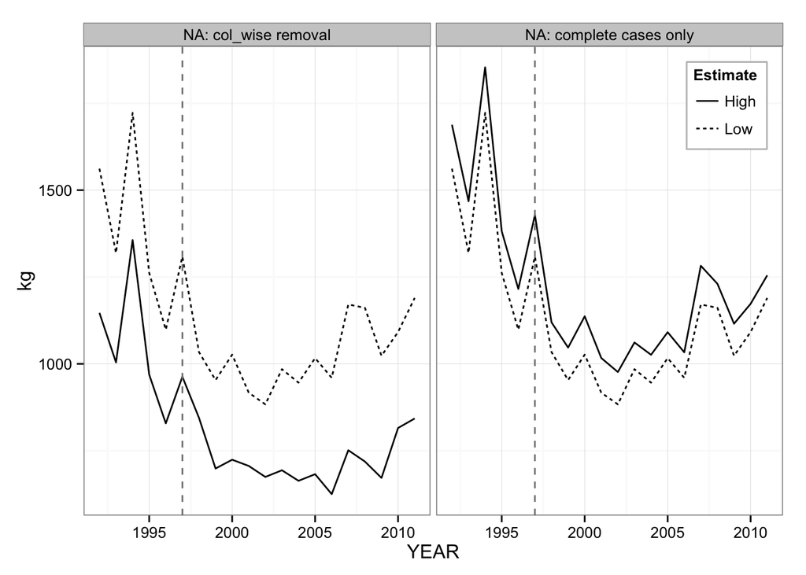

```r
year_na_sum2 <- rbind(year_na_sum, year_sum)

ggplot(year_na_sum2, aes(x = YEAR, y = kg)) +
  geom_line(aes(linetype = rate)) +
  scale_linetype("Estimate", labels = c("High", "Low"))+
  geom_vline(xintercept = 1997, colour = "grey50", linetype = "dashed")+
  facet_wrap(~ na_type) +
  theme_bw() +
  theme(legend.position = c(1,1),
        legend.justification = c(1,1),
        legend.key = element_blank(),
        legend.background = element_rect(colour = "grey"))
```

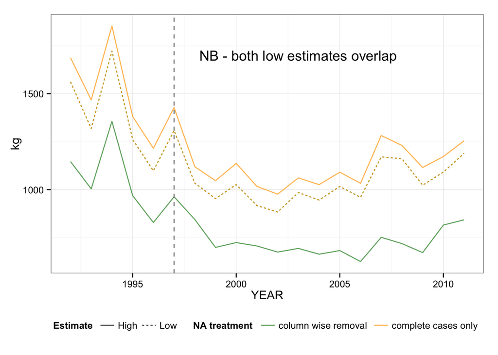

```r
ggplot(year_na_sum2, aes(x = YEAR, y = kg)) +
  geom_line(aes(linetype = rate, colour = na_type), alpha = 0.7) +
  scale_linetype("Estimate", labels = c("High", "Low"))+
  annotate(geom = "text", label = "NB - both low estimates overlap",
           x = 2003, y = 1700) +
  scale_colour_manual("NA treatment", values = c("forestgreen", "orange"),
                      labels = c("column wise removal", "complete cases only"))+
  geom_vline(xintercept = 1997, colour = "grey50", linetype = "dashed")+
  theme_bw() +
  theme(legend.key = element_blank(),
        legend.position = "bottom",
        legend.box = "horizontal")
```

So the question is whether we just use the high estimates, or just the low estimates, or both. If we use both I suggest we use the complete cases.

I will do the by county pesticide usage once we’ve decided what to do with the NAs, because the same thing applies.

## By county summary of application rates

I don’t print the tables, but that’s where the good data are. Graphs for illustration purposes but are sometimes summaries of data.

```r
names(pesticidesna)
```

```
##  [1] "X"                "GEOID"            "YEAR"
##  [4] "STATE_FIPS_CODE"  "COUNTY_FIPS_CODE" "COMPOUND"
##  [7] "State"            "County.Name"      "ANSI.class"
## [10] "KG_EPhigh"        "KG_EPlow"         "USPS"
## [13] "ANSICODE"         "NAME"             "POP10"
## [16] "HU10"             "ALAND"            "AWATER"
## [19] "ALAND_SQMI"       "AWATER_SQMI"      "INTPTLAT"
## [22] "INTPTLONG"        "PredPix"          "reclass"
## [25] "kg_km2agri_high"  "kg_km2agri_low"
```

```r
counties_sum <- pesticidesna %>%
  group_by(County.Name) %>%
  summarise(high_applic = mean(KG_EPhigh),
            low_applic = mean(KG_EPlow)) %>%
  gather(., rate, kg, high_applic:low_applic) %>%
  mutate(na_type = "NA: complete cases only")

head(counties_sum)
```

```
## Source: local data frame [6 x 4]
##
##        County.Name        rate     kg                 na_type
## 1     Adams County high_applic  589.4 NA: complete cases only
## 2     Allen County high_applic 1396.4 NA: complete cases only
## 3   Ashland County high_applic  858.1 NA: complete cases only
## 4 Ashtabula County high_applic  784.2 NA: complete cases only
## 5    Athens County high_applic  157.8 NA: complete cases only
## 6  Auglaize County high_applic 1883.0 NA: complete cases only
```

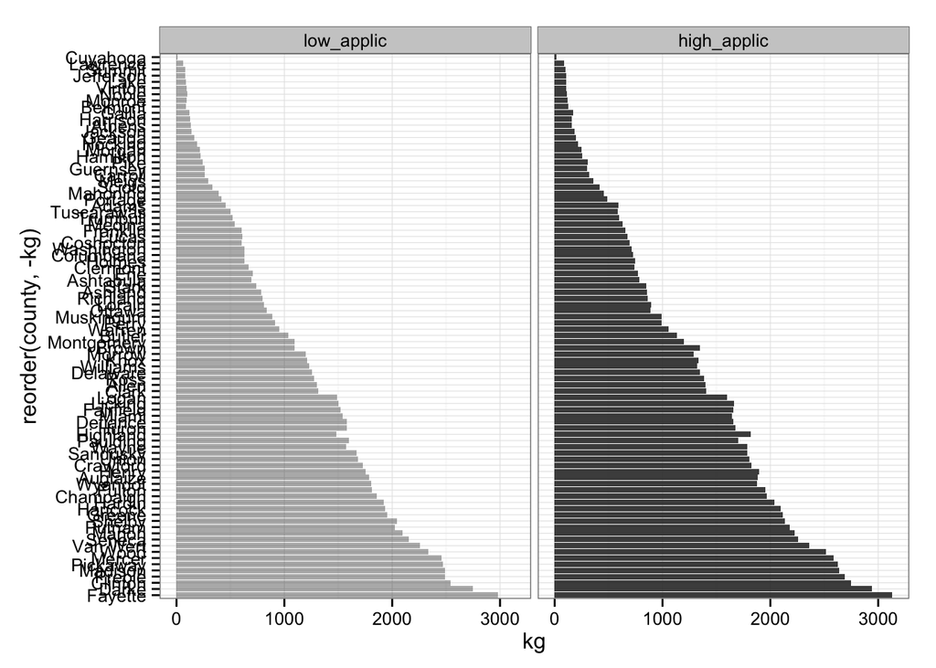

```r
counties_sum$rate <- factor(counties_sum$rate,
                            levels = c("low_applic", "high_applic"),
                            ordered = TRUE)
counties_sum$county <- gsub(" County", "", as.character(counties_sum$County.Name))

ggplot(counties_sum, aes(x = reorder(county, -kg), alpha = rate, y = kg)) +
  geom_bar(stat = "identity", position = position_dodge()) +
  scale_alpha_manual(values = c(0.4, 0.9))+
  theme_bw()+
  guides(alpha= FALSE)+
  facet_wrap(~rate)+
  coord_flip()
```

## Pesticides increasing/decreasing? - rates

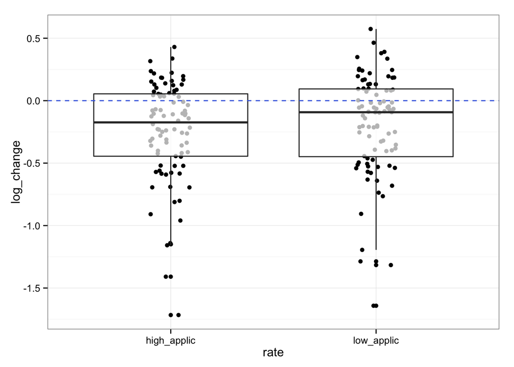

```r
counties_sum_table <- pesticidesna %>%
  filter(YEAR > 1996) %>%  ## remove this if wanted
  group_by(County.Name) %>%
  summarise(high_applic = mean(KG_EPhigh),
            low_applic = mean(KG_EPlow)) %>%
  mutate(county = gsub(" County", "", as.character(County.Name))) %>%
  select(county, low_applic, high_applic)

counties_change_table <- pesticidesna %>%
  filter(YEAR %in% c(1997, 2011)) %>%  ## remove this if wanted
  group_by(County.Name, YEAR) %>%
  summarise(high_applic = mean(KG_EPhigh),
            low_applic = mean(KG_EPlow)) %>%
  mutate(county = gsub(" County", "", as.character(County.Name))) %>%
  gather(., rate, kg, high_applic:low_applic) %>%
  spread(., YEAR, kg)%>%
  rename(start97 = `1997`, end11 = `2011`) %>%
  mutate(change = end11 / start97,
         log_change = log(end11 / start97))

ggplot(counties_change_table, aes(x = rate, y = log_change)) +
  geom_point(position = position_jitter(width = .1)) +
  geom_boxplot(alpha = 0.7) + theme_bw() +
  geom_hline(yintercept = log(1), linetype = "dashed", colour = "royalblue")
```

## Raw and average change between 1997 and 2011

```
## geom_smooth: method="auto" and size of largest group is <1000, so using loess. Use 'method = x' to change the smoothing method.
```

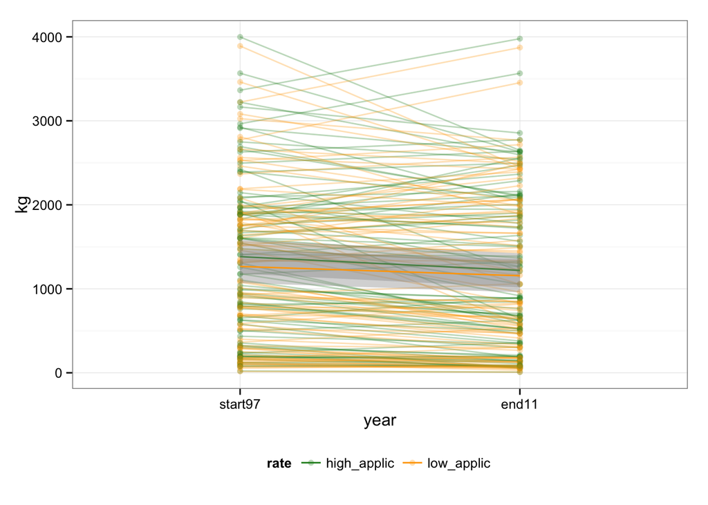

```r
counties_change_table_long <- counties_change_table %>%
  gather(., year, kg, start97:end11) %>%
  select(County.Name, county, rate, year, kg) %>%
  mutate(county_rate = interaction(county, rate))  ## this line is for ggplot grouping


ggplot(counties_change_table_long, aes(x = year, y = kg)) +
  geom_line(aes(group = county_rate, colour = rate), alpha = 0.3) +
  scale_colour_manual(values = c("forestgreen", "orange"))+
  geom_point(aes(colour = rate), alpha = 0.3) +
  geom_smooth(aes(group = rate, colour = rate)) +
  guides(colour = guide_legend(override.aes = list(fill = NA)))+
  theme(legend.position = "bottom", legend.key = element_blank())
```

## And the neonics

```r
neonics <- read.csv("../Pesticides/OH.neonicotinoids.csv")
head(neonics, 2)
```

```
##   GEOID     COMPOUND YEAR STATE_FIPS_CODE COUNTY_FIPS_CODE KG_EPhigh
## 1 18001 IMIDACLOPRID 1997              18                1       0.4
## 2 18001 IMIDACLOPRID 2004              18                1      75.8
##   KG_EPlow USPS ANSICODE         NAME POP10  HU10     ALAND  AWATER
## 1      0.4   IN   450401 Adams County 34387 13014 878079128 2430463
## 2     75.2   IN   450401 Adams County 34387 13014 878079128 2430463
##   ALAND_SQMI AWATER_SQMI INTPTLAT INTPTLONG density_low density_high
## 1        339       0.938    40.75    -84.94     0.00118      0.00118
## 2        339       0.938    40.75    -84.94     0.22181      0.22358
```

```r
range(neonics$YEAR)
```

```
## [1] 1995 2011
```

Tyson: here I use density_high, which from memory is the application rate (high in this case) over the county area? Let me know if you think a different measure is better hey.

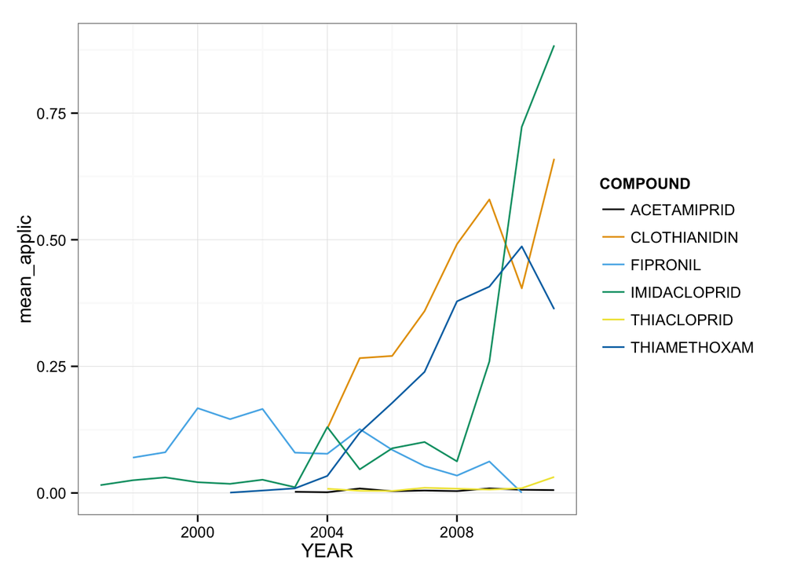

```r
neonics_year <- neonics %>%
  filter(YEAR > 1996) %>%
  group_by(YEAR, COMPOUND) %>%
  summarise(mean_applic = mean(density_high), na.rm = TRUE)

ggplot(neonics_year, aes(x = YEAR, y = mean_applic)) +
  geom_line(aes(colour = COMPOUND)) +
  scale_colour_colorblind() +
  theme(legend.key = element_blank())
```

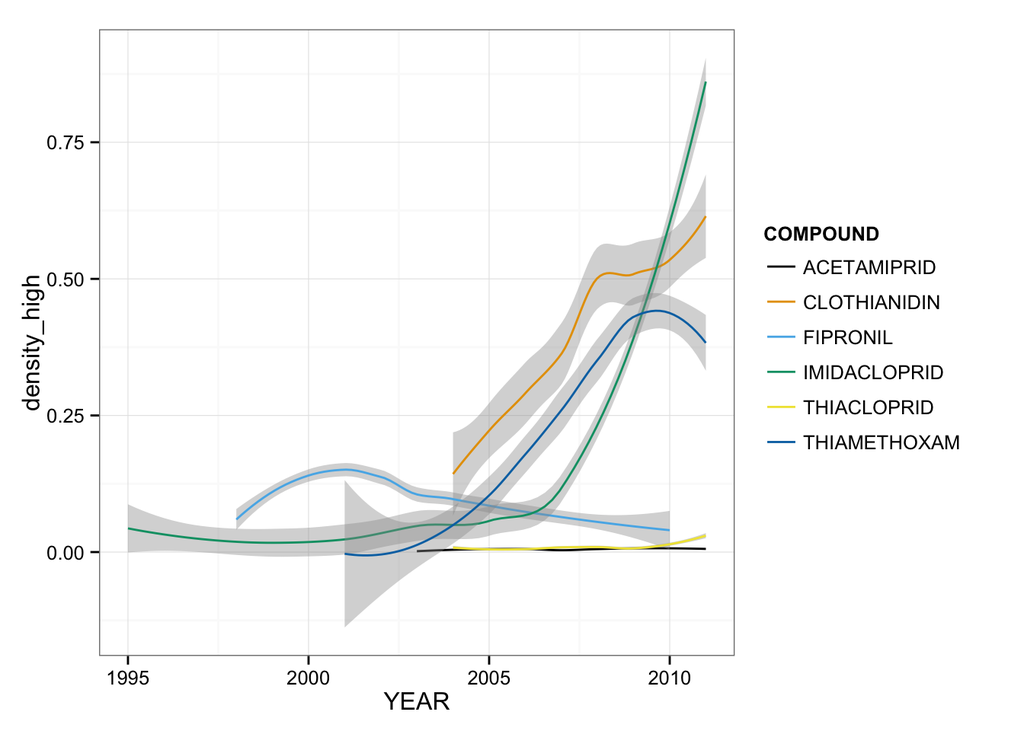

```r
# and using a smoothed version
ggplot(neonics, aes(x = YEAR, y = density_high)) +
  geom_smooth(aes(colour = COMPOUND), method = "loess") + # doesn't work with gam - x range/knots issue
    guides(colour = guide_legend(override.aes = list(fill = NA)))+
  scale_colour_colorblind() +
  theme(legend.key = element_blank())
```

And by county. Note I haven’t dealt to the NAs for neonics - just leaving that until we decide what to do. Also just using high kg for now.

```r
names(neonics)
```

```
##  [1] "GEOID"            "COMPOUND"         "YEAR"
##  [4] "STATE_FIPS_CODE"  "COUNTY_FIPS_CODE" "KG_EPhigh"
##  [7] "KG_EPlow"         "USPS"             "ANSICODE"
## [10] "NAME"             "POP10"            "HU10"
## [13] "ALAND"            "AWATER"           "ALAND_SQMI"
## [16] "AWATER_SQMI"      "INTPTLAT"         "INTPTLONG"
## [19] "density_low"      "density_high"
```

```r
head(neonics, 1)
```

```
##   GEOID     COMPOUND YEAR STATE_FIPS_CODE COUNTY_FIPS_CODE KG_EPhigh
## 1 18001 IMIDACLOPRID 1997              18                1       0.4
##   KG_EPlow USPS ANSICODE         NAME POP10  HU10     ALAND  AWATER
## 1      0.4   IN   450401 Adams County 34387 13014 878079128 2430463
##   ALAND_SQMI AWATER_SQMI INTPTLAT INTPTLONG density_low density_high
## 1        339       0.938    40.75    -84.94     0.00118      0.00118
```

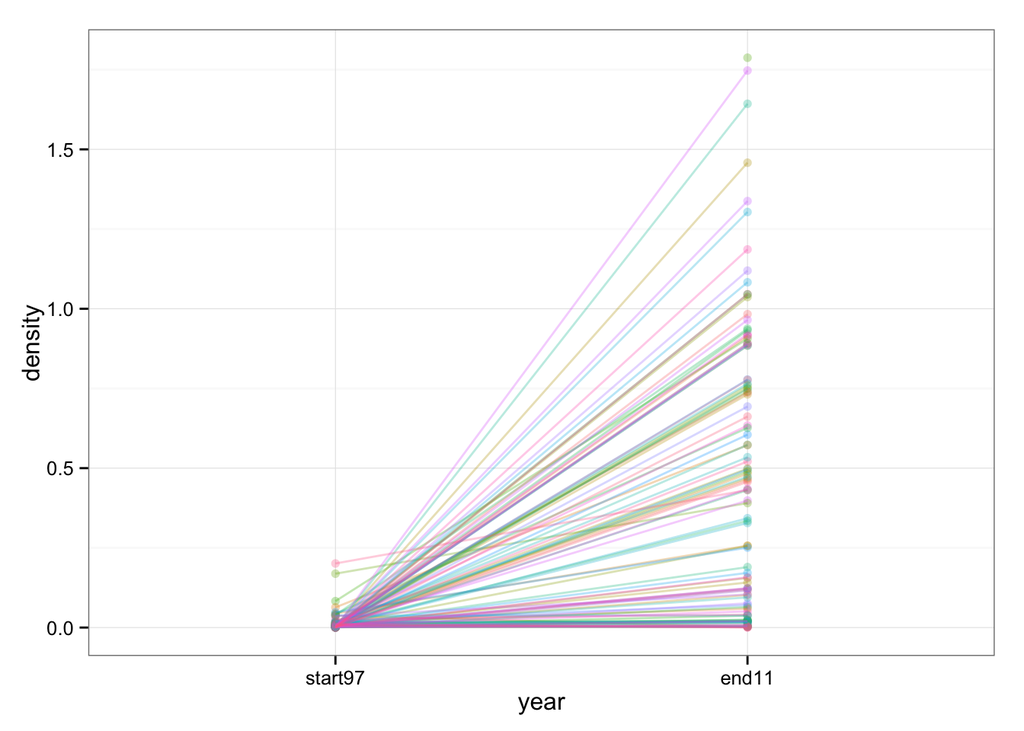

```r
counties_neonics_change_table <- neonics %>%
  filter(YEAR %in% c(1997, 2011)) %>%  ## remove this if wanted
  group_by(NAME, YEAR) %>%
  summarise(high_applic = mean(density_high)) %>%
  mutate(county = gsub(" County", "", as.character(NAME))) %>%
  ungroup() %>%
  spread(., YEAR, high_applic) %>%
  rename(start97 = `1997`, end11 = `2011`) %>%
  mutate(change = end11 / start97,
         log_change = log(end11 / start97)) %>%
  arrange(-change)

counties_neonics_change_table_short <- counties_neonics_change_table %>%
  gather(year, density, start97:end11)

ggplot(counties_neonics_change_table_short, aes(x = year, y = density)) +
  geom_point(aes(colour = county), alpha = 0.3) +
  geom_line(aes(colour = county, group = county), alpha = 0.3)+
  guides(colour = FALSE)
```

Also, extra for experts, by compound:

```r
# err, object names are getting long.. soz


head(neonics)
```

```
##   GEOID     COMPOUND YEAR STATE_FIPS_CODE COUNTY_FIPS_CODE KG_EPhigh
## 1 18001 IMIDACLOPRID 1997              18                1       0.4
## 2 18001 IMIDACLOPRID 2004              18                1      75.8
## 3 18001 IMIDACLOPRID 1998              18                1       0.1
## 4 18001 IMIDACLOPRID 2001              18                1       0.4
## 5 18001 THIAMETHOXAM 2009              18                1     432.9
## 6 18001 IMIDACLOPRID 1999              18                1       3.6
##   KG_EPlow USPS ANSICODE         NAME POP10  HU10     ALAND  AWATER
## 1      0.4   IN   450401 Adams County 34387 13014 878079128 2430463
## 2     75.2   IN   450401 Adams County 34387 13014 878079128 2430463
## 3       NA   IN   450401 Adams County 34387 13014 878079128 2430463
## 4      0.1   IN   450401 Adams County 34387 13014 878079128 2430463
## 5    432.9   IN   450401 Adams County 34387 13014 878079128 2430463
## 6      3.6   IN   450401 Adams County 34387 13014 878079128 2430463
##   ALAND_SQMI AWATER_SQMI INTPTLAT INTPTLONG density_low density_high
## 1        339       0.938    40.75    -84.94    0.001180     0.001180
## 2        339       0.938    40.75    -84.94    0.221811     0.223580
## 3        339       0.938    40.75    -84.94          NA     0.000295
## 4        339       0.938    40.75    -84.94    0.000295     0.001180
## 5        339       0.938    40.75    -84.94    1.276886     1.276886
## 6        339       0.938    40.75    -84.94    0.010619     0.010619
```

```r
counties_neonics_change_table_compound <- neonics %>%
  filter(YEAR %in% c(1997, 2011)) %>%  ## remove this if wanted
  group_by(NAME, YEAR, COMPOUND) %>%
  summarise(high_applic = mean(density_high)) %>%
  mutate(county = gsub(" County", "", as.character(NAME))) %>%
reshape2::dcast(NAME + county + COMPOUND ~ YEAR, value.var = "high_applic") %>%
  rename(start97 = `1997`, end11 = `2011`)
counties_neonics_change_table_compound[is.na(counties_neonics_change_table_compound$start97), "start97"] <- 0
counties_neonics_change_table_compound[is.na(counties_neonics_change_table_compound$end11), "end11"] <- 0
head(counties_neonics_change_table_compound, 3)
```

```
##           NAME county     COMPOUND start97    end11
## 1 Adams County  Adams  ACETAMIPRID 0.00000 0.003254
## 2 Adams County  Adams CLOTHIANIDIN 0.00000 0.604686
## 3 Adams County  Adams IMIDACLOPRID 0.01583 1.649822
```

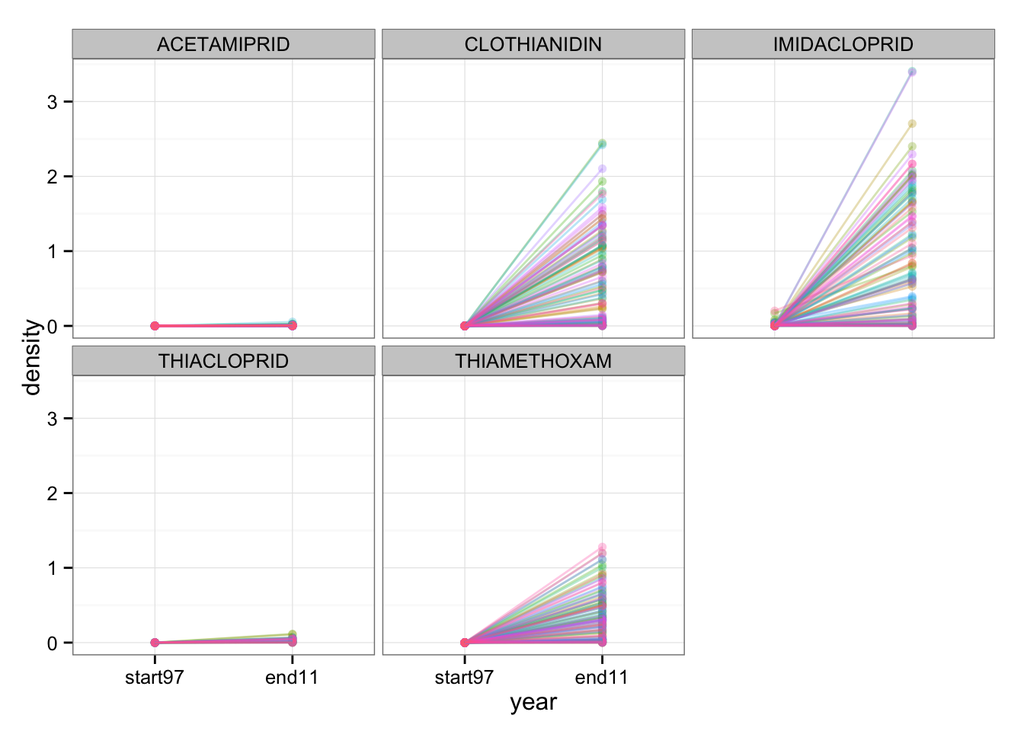

```r
counties_neonics_change_table_compound_short <- counties_neonics_change_table_compound %>%
  gather(year, density, start97:end11)

ggplot(counties_neonics_change_table_compound_short, aes(x = year, y = density)) +
  geom_point(aes(colour = county), alpha = 0.3) +
  geom_line(aes(colour = county, group = county), alpha = 0.3)+
  guides(colour = FALSE) +
  facet_wrap(~ COMPOUND)
```

## Question re the above

Problem is of course lots of the neonics hadn’t started in 97 - therefore what summary statistic we want out? Let me know or code in yourself - that will be pretty easy.